# Models of cultural transmission in human populations

Workshop for Genspace

Mason Youngblood

May 8th, 2021

This workshop is loosely based on the framework outlined in Acerbi and colleagues’ free digital book entitled [Individual-based models of cultural evolution](https://acerbialberto.com/IBM-cultevo/). The lecture portion of the workshop is not included in this R Markdown document.

We will start out with a basic agent-based model of unbiased transmission where agents choose between A or B. Agents randomly choose another agent’s trait at the start of each generation, and are able to copy any agent in the population. This means that if in the first generation 60% of the agents in the population express A, then the probability of an agent in the second generation adopting A will be 60%.

# 1 Unbiased Transmission

The first thing we need to do is load our packages.

```r
library(data.table)
library(parallel)
library(igraph)
library(scales)
```

Then we need to decide how big the population will be, and how many generations the simulation will run for.

```r
N <- 100
t_max <- 100
```

The next thing we need to do is create a population of agents with either trait A or B. By default the `sample` functions assumes an equal probability of A or B, but we can change this later.

```r
population <- data.table(trait = sample(c("A", "B"), N, replace = TRUE))
```

We also need to create a vector where the output of the simulations will be stored, in this case the proportion of agents with trait A. Since we already have data for the first generation of the population we can go ahead and fill in the first entry in the output vector.

```r
output <- rep(NA, t_max)
output[1] <- sum(population$trait == "A")/N
```

Next we need to write a for loop to run the simulation for the rest of the generations. At the start of each generation, we need to calculate the probability that each agent adopts trait A or B. This line goes through each agent individually, and calculates the probability that they will adopt A or B based on the frequencies of A and B in the population. This is not the most efficient way of doing it, but it is easier to add more complexity to this format later. Once we have the probabilities we can simulate the learning process. The `set` function for data tables is faster than other methods. For each member of the population, we randomly choose either A or B based on the probabilities calculated in the previous step. Lastly we calculate the proportion of the population with A and put it into the output slot for this generation. Make sure that you always comment your code!

```r
for(t in 2:t_max){
  #calculate probabilities
  probs <- lapply(1:N, function(x){as.numeric(table(factor(population$trait, levels = c("A", "B"))))})

  #copy from previous generation
  set(population, j = "trait", value = sapply(1:N, function(x){sample(c("A", "B"), 1, prob = probs[[x]])}))

  #get p and put it into the output slot for this generation t
  output[t] <- sum(population$trait == "A")/N
}
```

Once we have the output for all of the generations, we can plot the results. Here we are using the base R `plot` capabilities rather than `ggplot`, which is prettier but really slow for large and complex datasets. `matplot` is designed for multiple columns of data, but works just as well for a single vector. We will also set the default plot margins so that our output doesn’t have extra space around it (this will be added every time we plot).

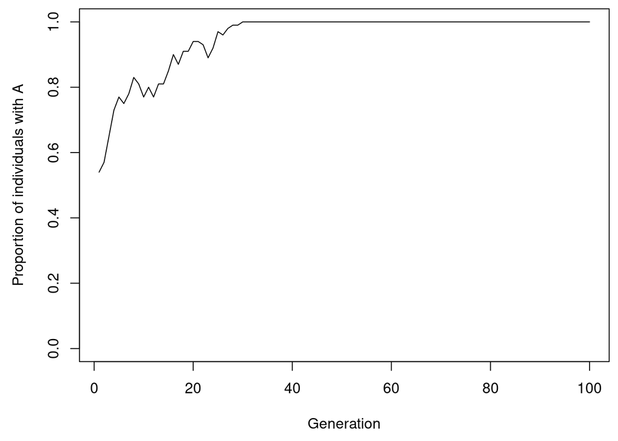

```r
par(mar = c(4.5, 4.5, 0.5, 0.5))
matplot(output, type = "l", xlab = "Generation", ylab = "Proportion of individuals with A", lty = 1, col = alpha("black", 1), ylim = c(0, 1))
```

To make this easier on ourselves, we can put all of this into a single function that we can call with one line of code. In the function definition we can specify the default values we want for each parameter, but we can always specify something different when we call the function later.

```r
transmission <- function(N = 100, p_0 = 0.5, t_max = 100){
  #create population of agents with either trait A or B
  population <- data.table(trait = sample(c("A", "B"), N, replace = TRUE, prob = c(p_0, 1-p_0)))

  #create output vector
  output <- rep(NA, t_max)

  #store first generation's p for run r
  output[1] <- sum(population$trait == "A")/N

  #for each generation
  for(t in 2:t_max){
    #calculate probabilities
    probs <- lapply(1:N, function(x){as.numeric(table(factor(population$trait, levels = c("A", "B"))))})

    #copy from previous generation
    set(population, j = "trait", value = sapply(1:N, function(x){sample(c("A", "B"), 1, prob = probs[[x]])}))

    #get p and put it into the output slot for this generation t
    output[t] <- sum(population$trait == "A")/N
  }

  #return output from function
  return(output)
}
```

Now let’s call the function and plot the results.

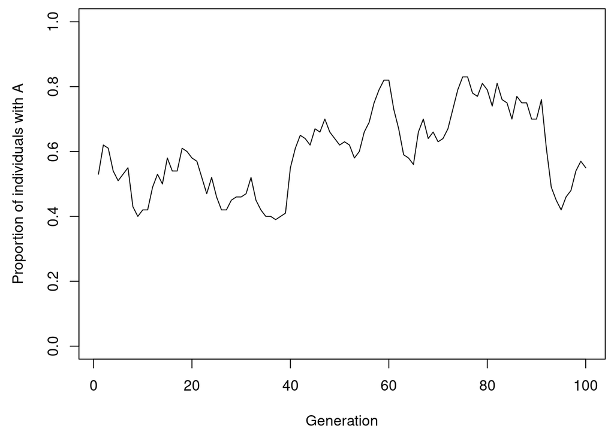

```r
output <- transmission()
par(mar = c(4.5, 4.5, 0.5, 0.5))
matplot(output, type = "l", xlab = "Generation", ylab = "Proportion of individuals with A", lty = 1, col = alpha("black", 1), ylim = c(0, 1))
```

In agent-based modeling we’re almost always more interested in what happens, on average, when you run a model many times. Let’s try that here! Since it’s not a particularly efficient model we’ll do all of this using parallel processing. `mclapply` works just like `lapply`. First let’s set the number of iterations we want. Then let’s run the function with the default parameters for that many iterations. If you’re unsure about the number of available cores in your computer, just use 1 instead. Then convert the list of vectors into a matrix for plotting, and plot it all with one line of code. The number in `alpha` corresponds to the opacity of the black lines. We can also add a line that shows the average value across all of the simulations using `lines`.

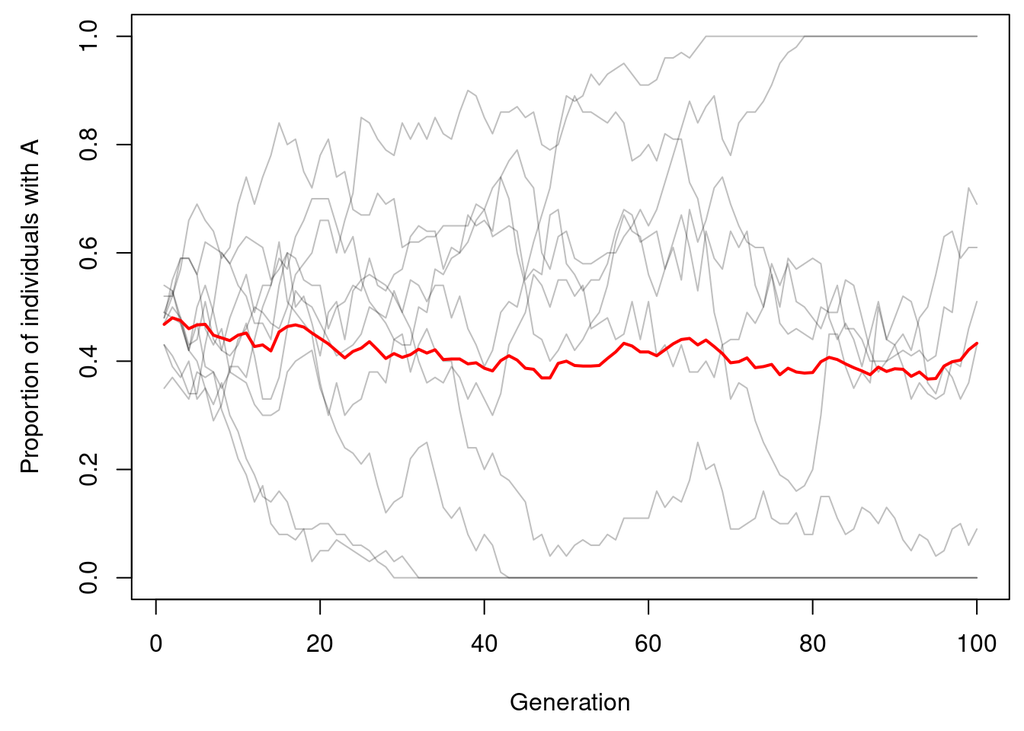

```r
iter <- 10
output <- mclapply(1:iter, function(x){transmission()}, mc.cores = 4)
output <- matrix(unlist(output), ncol = iter)
par(mar = c(4.5, 4.5, 0.5, 0.5))
matplot(output, type = "l", xlab = "Generation", ylab = "Proportion of individuals with A", lty = 1, col = alpha("black", 0.25), ylim = c(0, 1))
lines(rowMeans(output), col = "red", lwd = 2)
```

As you can see the results are pretty chaotic when we use a small population size. Let’s use a higher population size and see what happens.

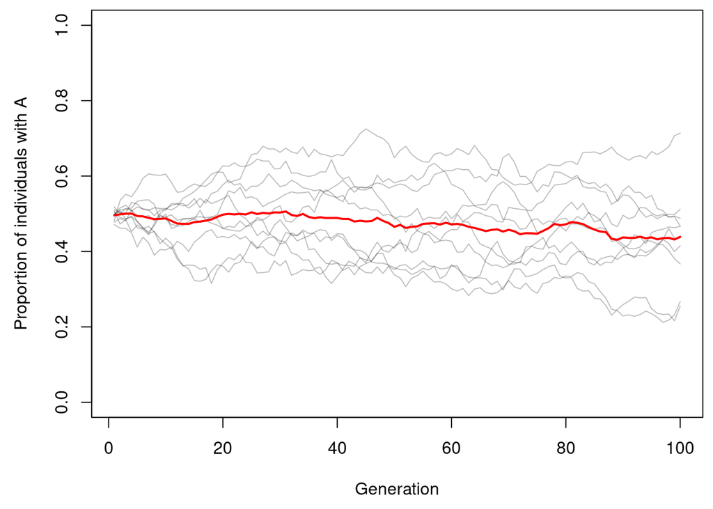

```r
iter <- 10
output <- mclapply(1:iter, function(x){transmission(N = 1000)}, mc.cores = 4)
output <- matrix(unlist(output), ncol = iter)
par(mar = c(4.5, 4.5, 0.5, 0.5))
matplot(output, type = "l", xlab = "Generation", ylab = "Proportion of individuals with A", lty = 1, col = alpha("black", 0.25), ylim = c(0, 1))
lines(rowMeans(output), col = "red", lwd = 2)
```

With a higher population size the results are much more stable. This is because, just like in biological evolution, random fluctuations in trait frequency have a smaller effect in larger populations!

# 2 Content Bias

Now let’s add a parameter for content bias. To do this we will just multiply the frequency of trait A by `content`, where values > 1 increase the probability of adopting A and values < 1 decrease the probability of adopting A.

```r
transmission <- function(N = 100, p_0 = 0.5, t_max = 100, content = 1){
  #create population of agents with either trait A or B
  population <- data.table(trait = sample(c("A", "B"), N, replace = TRUE, prob = c(p_0, 1-p_0)))

  #create output vector
  output <- rep(NA, t_max)

  #store first generation's p for run r
  output[1] <- sum(population$trait == "A")/N

  #for each generation
  for(t in 2:t_max){
    #calculate probabilities
    probs <- lapply(1:N, function(x){as.numeric(table(factor(population$trait, levels = c("A", "B"))))*c(content, 1)})

    #copy from previous generation
    set(population, j = "trait", value = sapply(1:N, function(x){sample(c("A", "B"), 1, prob = probs[[x]])}))

    #get p and put it into the output slot for this generation t
    output[t] <- sum(population$trait == "A")/N
  }

  #return output from function
  return(output)
}
```

Let’s see what happens when we simulate content bias for A (`content = 1.1`) from a starting point where A is rare (`p_0 = 0.1`).

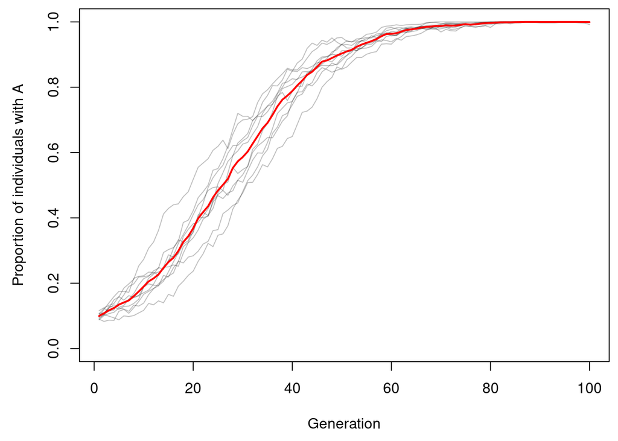

```r
iter <- 10
output <- mclapply(1:iter, function(x){transmission(N = 1000, p_0 = 0.1, content = 1.1)}, mc.cores = 8)
output <- matrix(unlist(output), ncol = iter)
par(mar = c(4.5, 4.5, 0.5, 0.5))
matplot(output, type = "l", xlab = "Generation", ylab = "Proportion of individuals with A", lty = 1, col = alpha("black", 0.25), ylim = c(0, 1))
lines(rowMeans(output), col = "red", lwd = 2)
```

Even with a weak level of content bias the population quickly converges towards A.

# 3 Frequency Bias

Now let’s add a parameter for frequency bias. To do this we will just raise the frequencies of trait A and B by `frequency`, where values > 1 advantage the common trait and values < 1 advantage the rare trait.

```r
transmission <- function(N = 100, p_0 = 0.5, t_max = 100, content = 1, frequency = 1){
  #create population of agents with either trait A or B
  population <- data.table(trait = sample(c("A", "B"), N, replace = TRUE, prob = c(p_0, 1-p_0)))

  #create output vector
  output <- rep(NA, t_max)

  #store first generation's p for run r
  output[1] <- sum(population$trait == "A")/N

  #for each generation
  for(t in 2:t_max){
    #calculate probabilities
    probs <- lapply(1:N, function(x){(as.numeric(table(factor(population$trait, levels = c("A", "B"))))^frequency)*c(content, 1)})

    #copy from previous generation
    set(population, j = "trait", value = sapply(1:N, function(x){sample(c("A", "B"), 1, prob = probs[[x]])}))

    #get p and put it into the output slot for this generation t
    output[t] <- sum(population$trait == "A")/N
  }

  #return output from function
  return(output)
}
```

Let’s compare the results of conformity bias and novelty bias. First let’s try out conformity bias (`frequency = 1.1`) from a starting point where A is relatively common (`p_0 = 0.6`).

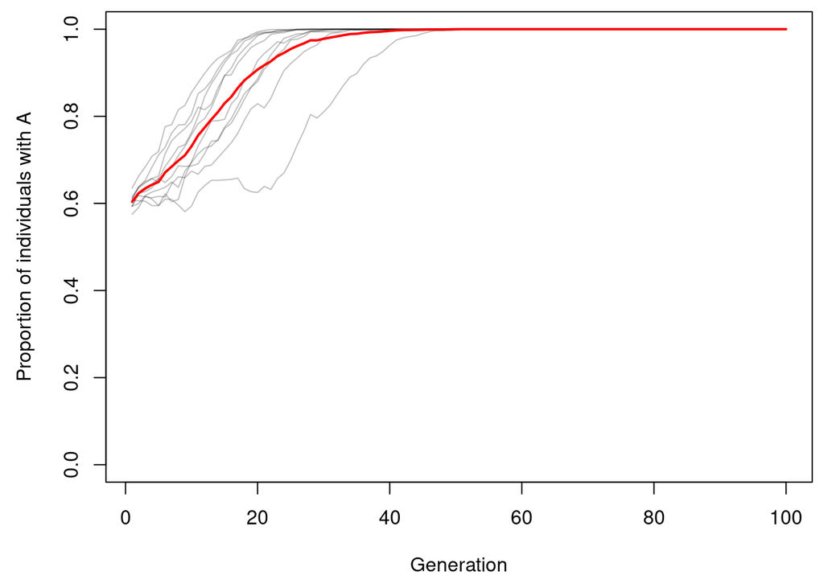

```r
iter <- 10
output <- mclapply(1:iter, function(x){transmission(N = 1000, p_0 = 0.6, frequency = 1.1)}, mc.cores = 8)
output <- matrix(unlist(output), ncol = iter)
par(mar = c(4.5, 4.5, 0.5, 0.5))
matplot(output, type = "l", xlab = "Generation", ylab = "Proportion of individuals with A", lty = 1, col = alpha("black", 0.25), ylim = c(0, 1))
lines(rowMeans(output), col = "red", lwd = 2)
```

As you can see the population very rapidly adopts A, which is in this case the most common trait. Now let’s try out novelty bias (`frequency = 0.9`) from the same starting point.

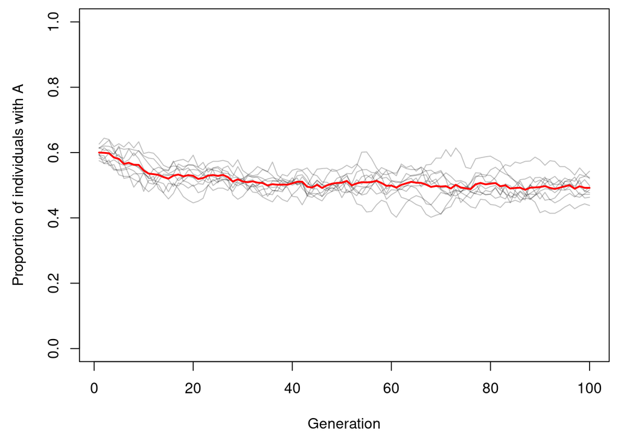

```r
iter <- 10
output <- mclapply(1:iter, function(x){transmission(N = 1000, p_0 = 0.6, frequency = 0.9)}, mc.cores = 8)
output <- matrix(unlist(output), ncol = iter)
par(mar = c(4.5, 4.5, 0.5, 0.5))
matplot(output, type = "l", xlab = "Generation", ylab = "Proportion of individuals with A", lty = 1, col = alpha("black", 0.25), ylim = c(0, 1))
lines(rowMeans(output), col = "red", lwd = 2)
```

# 4 Population Structure

Now let’s add a parameter for population structure. We will be modeling the population with stochastic block modeling via the package `igraph`. Stochastic block models generate clusters of nodes that are more connected with each other than with nodes from other clusters. These communities are similar in structure to those on social media platforms. To do this we will add two parameters: `clusters`, or the number of clusters in the population, and `edge_prob`, the probability that those clusters are connected to one another. Here is an example of what a stochastic block modeling network looks like, with `N = 100`, `clusters = 5`, and `edge_prob = 0.01`.

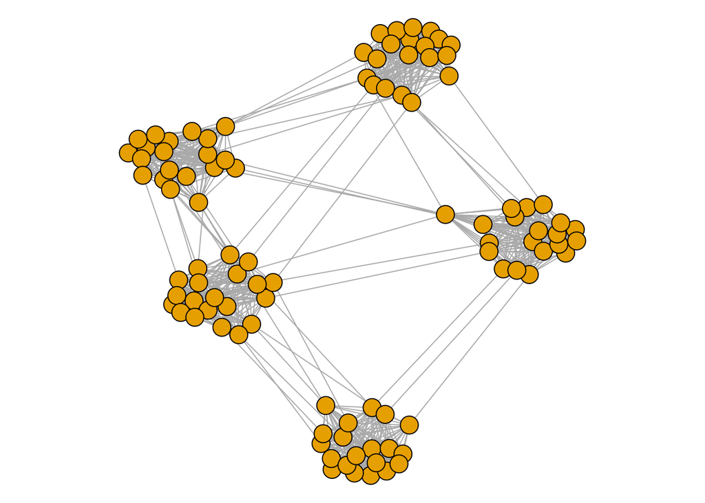

```r
#create matrix of connection probability between clusters
pref_matrix <- matrix(0.01, nrow = 5, ncol = 5)
diag(pref_matrix) <- 1

#create and plot population structure
structure <- sample_sbm(100, pref_matrix, rep(100/5, 5))
par(mar = c(0, 0, 0, 0))
plot(structure, vertex.label = NA, vertex.size = 8)
```

This structure will be added to our function, and used to determine who each agent will learn from. Previously agents were assumed to have access to the traits of all other agents, but now they will only have access to agents that they are directly connected to. To do this we will add a `connections` column to the population table that contains all the agents an agent is connected to, and when trait probabilities are calculated only the traits of those agents will be considered. Also, instead of assigning traits at random we will assign them so that individuals in the same cluster tend to have the same traits. To do this all we need to do is add `sort` when traits are sampled, since the ID’s of agents in the same cluster are consecutive in the data table.

```r
transmission <- function(N = 100, p_0 = 0.5, t_max = 100, content = 1, frequency = 1, clusters = 5, edge_prob = 0.01){
  #create output vector
  output <- rep(NA, t_max)

  #create population structure using stochastic block modeling
  pref_matrix <- matrix(edge_prob, nrow = clusters, ncol = clusters)
  diag(pref_matrix) <- 1
  structure <- sample_sbm(N, pref_matrix, rep(N/clusters, clusters))

  #create population of agents with either trait A or B
  population <- data.table(trait = sort(sample(c("A", "B"), N, replace = TRUE, prob = c(p_0, 1-p_0))))

  #add connections to population table
  population$connections <- lapply(1:N, function(x){which(structure[x] > 0)})

  #store first generation's p for run r
  output[1] <- sum(population$trait == "A")/N

  #for each generation
  for(t in 2:t_max){
    #calculate probabilities
    probs <- lapply(1:N, function(x){(as.numeric(table(factor(population$trait[population$connections[[x]]], levels = c("A", "B"))))^frequency)*c(content, 1)})

    #copy from previous generation
    set(population, j = "trait", value = sapply(1:N, function(x){sample(c("A", "B"), 1, prob = probs[[x]])}))

    #get p and put it into the output slot for this generation t
    output[t] <- sum(population$trait == "A")/N
  }

  #return output from function
  return(output)
}
```

Let’s see what happens if we run the same frequency bias example as before, but this time taking into account population structure.

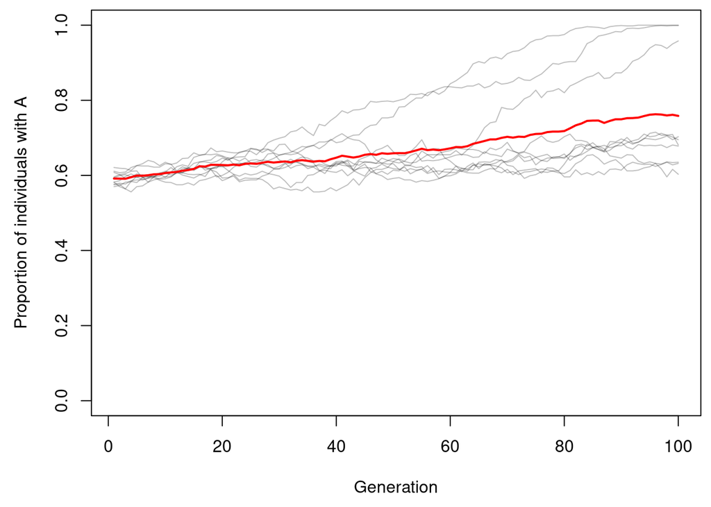

```r
iter <- 10
output <- mclapply(1:iter, function(x){transmission(N = 1000, p_0 = 0.6, frequency = 1.1, clusters = 5, edge_prob = 0.01)}, mc.cores = 8)
output <- matrix(unlist(output), ncol = iter)
par(mar = c(4.5, 4.5, 0.5, 0.5))
matplot(output, type = "l", xlab = "Generation", ylab = "Proportion of individuals with A", lty = 1, col = alpha("black", 0.25), ylim = c(0, 1))
lines(rowMeans(output), col = "red", lwd = 2)
```

This time the population converges towards A much more slowly, because the trait takes longer to diffuse through the fragmented communities. The same is true if you run novelty bias with population structure. Interestingly, we do not see the same effect for content bias.

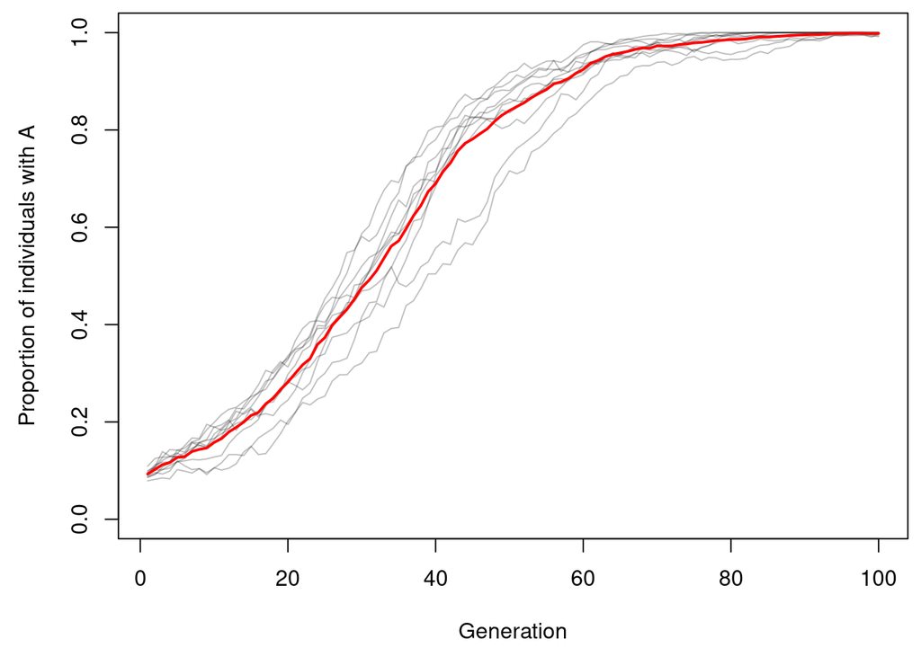

```r
iter <- 10
output <- mclapply(1:iter, function(x){transmission(N = 1000, p_0 = 0.1, content = 1.1, clusters = 5, edge_prob = 0.01)}, mc.cores = 8)
output <- matrix(unlist(output), ncol = iter)
par(mar = c(4.5, 4.5, 0.5, 0.5))
matplot(output, type = "l", xlab = "Generation", ylab = "Proportion of individuals with A", lty = 1, col = alpha("black", 0.25), ylim = c(0, 1))
lines(rowMeans(output), col = "red", lwd = 2)
```

This is because content bias affects the adoption of A independently of an agent’s position in the network, whereas the effect of frequency bias depends on social structure.